# Practical Machine Learning Project

Jose Gustavo Z. Rosa

20 de fevereiro de 2017

## The Project

### Project Setup

I usualy like to setup everything at the project beggining of the script.

So, here we go,

```r
library(caret)
```

```r
library(rpart)
library(rpart.plot)
library(RColorBrewer)
library(randomForest)
library(rattle)
# a quite obvious seed
set.seed(12345)
```

## The Data Sources

The training data for this project are available here:

https://d396qusza40orc.cloudfront.net/predmachlearn/pml-training.csv

The test data are available here:

https://d396qusza40orc.cloudfront.net/predmachlearn/pml-testing.csv

The data for this project comes from this original source: http://groupware.les.inf.puc-rio.br/har.

We will download the code directly from the URLS and cache them locally just to make things a little easier.

### Getting the data

First of all, lets setup a local folder to download and fetch data late on, and also a couple of variables to hold the actual file reference

```r
if(!file.exists("./Data")){dir.create("./Data")}

trainUrl <- "http://d396qusza40orc.cloudfront.net/predmachlearn/pml-training.csv"
testUrl <- "http://d396qusza40orc.cloudfront.net/predmachlearn/pml-testing.csv"

#downloading the files
localPath <- file.path("./Data")

if(!file.exists("./Data")) {
  download.file(trainUrl,destfile="./Data/train.csv",method="curl")
  download.file(testUrl,destfile="./Data/test.csv",method="curl")
}

#loading the actual data
trainFile <- read.csv(file.path(localPath, "train.csv" ),header = TRUE)
testFile <- read.csv(file.path(localPath, "test.csv" ),header = TRUE)
```

### Cleaning Data

At first we will clean only the trainning dataset, the idea is to leave only useful information for our purpose here and also and quite important as well is to remove columns with a “lot” of NA’s or even other mismatch data os some sort.

There are also some columns that where brought as ˜factors˜ but they should be numeric, so the next code chunk deals with these values as well.

```r
trainFile[trainFile == '#DIV/0!'] <- NA
trainFile[trainFile == ''] <- NA
# extra removal here, since these columns do not look like as usefull
trainFile <- trainFile[,-c(1:7)]

for(i in 1:(ncol(trainFile)-1)){
  if(class(trainFile[, i]) == 'factor'){
    trainFile[, i] <- as.numeric(as.character(trainFile[, i]))
  }
}
```

After this basic cleaning procedure, it’s important to check the “near zero variance” variables, since they might look usefull but actulally aren’t. Since we are dealing with data from sensors it’s quite a common scenario to handle this things. Also those same procedures must be applied to the provided test file (var name testFile in this project) in order to keep the analisys under the same base for further use in the predictors.

```r
nzv <- nearZeroVar(trainFile, saveMetrics = T)
removed.cols <- names(trainFile)[nzv$nzv]
trainFile <- trainFile[,!(nzv$nzv)]
```

### Partitioning the data

I approached the data partitioning in the same fashion as we saw on the lectures, using just two partitions (trainning and testing). I also used the preProcessing strategy to handle Missing values.

```r
inTrain <- createDataPartition(y=trainFile$classe, p=0.6, list=FALSE)
myTraining <- trainFile[inTrain, ]
myTesting <- trainFile[-inTrain, ]

preObj <- preProcess(myTraining[,-ncol(myTraining)], method="medianImpute")
myTraining <- predict(preObj, myTraining)

dim(myTraining)
```

```
## [1] 11776   118
```

```r
dim(myTesting)
```

```
## [1] 7846  118
```

## And Now, for the Machine Learning

### First a Decision Tree

First I’ll try the simple decision tree to check how it will perform on the trainning set. I also decided use a simple plot of the thee just to ilustrate its general aspect.

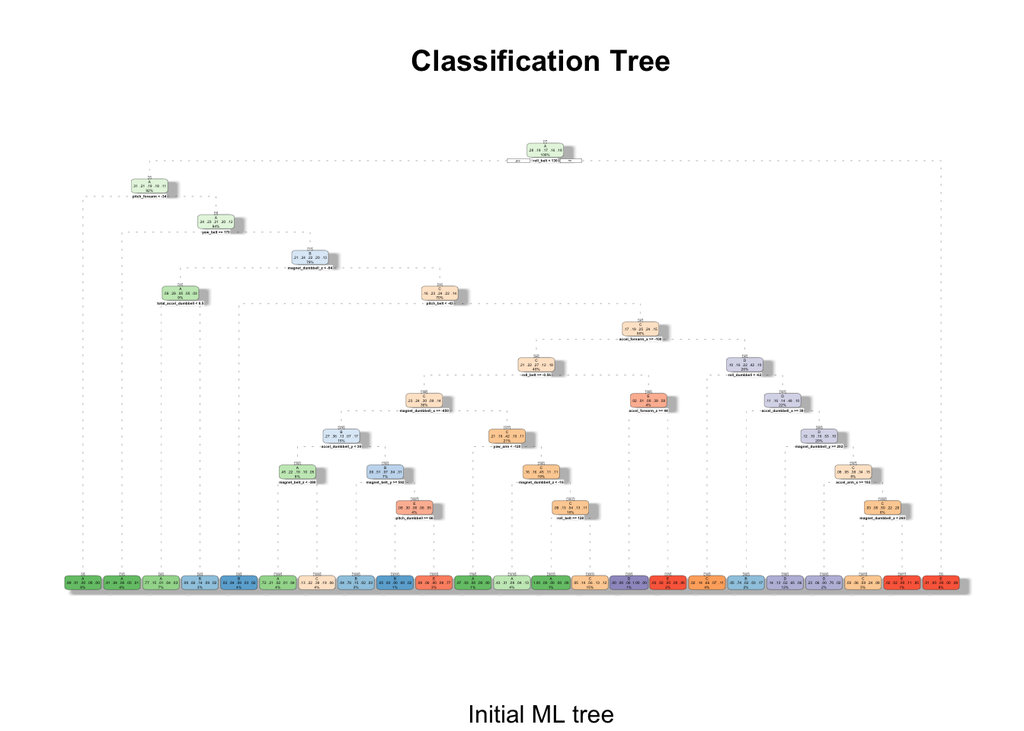

```r
modFitA1 <- rpart(classe ~ ., data=myTraining, method="class")
fancyRpartPlot(modFitA1,main = "Classification Tree", sub = "Initial ML tree")
```

## Predictions

The following predictions are based on the inital Tree model. I chose to use a simple barchart to build a more concise view of the data.

```r
predictionsA1 <- predict(modFitA1, myTesting, type = "class")
confusionMatrix(predictionsA1, myTesting$classe)
```

```
## Confusion Matrix and Statistics
##
##           Reference
## Prediction    A    B    C    D    E
##          A 1879  260   30   69   66
##          B   56  759   88   34   54
##          C  105  340 1226  354  234
##          D  155  132   23  807   57
##          E   37   27    1   22 1031
##
## Overall Statistics
##
##                Accuracy : 0.7267
##                  95% CI : (0.7167, 0.7366)
##     No Information Rate : 0.2845
##     P-Value [Acc > NIR] : < 2.2e-16
##
##                   Kappa : 0.6546
##  Mcnemar's Test P-Value : < 2.2e-16
##
## Statistics by Class:
##
##                      Class: A Class: B Class: C Class: D Class: E
## Sensitivity            0.8418  0.50000   0.8962   0.6275   0.7150
## Specificity            0.9243  0.96334   0.8405   0.9441   0.9864
## Pos Pred Value         0.8155  0.76589   0.5427   0.6874   0.9222
## Neg Pred Value         0.9363  0.88928   0.9746   0.9282   0.9389
## Prevalence             0.2845  0.19347   0.1744   0.1639   0.1838
## Detection Rate         0.2395  0.09674   0.1563   0.1029   0.1314
## Detection Prevalence   0.2937  0.12631   0.2879   0.1496   0.1425
## Balanced Accuracy      0.8831  0.73167   0.8684   0.7858   0.8507
```

### And Them a Randon Forest

note: I had a better performance of the randon forest execution using the doParallel package, as showed bellow, but Im sure if the demonstrated configuration will be good enough to other plataforms

```r
library(doParallel)
#adjust those paramenters to your computer...
registerDoParallel(cores=4)

cvCtrl <- trainControl('cv', 2, savePred=T)
modelb <- train(classe ~ ., data = myTraining, method = 'rf', trControl = cvCtrl)
```

So, Random forest went a quite better… Here is the chart

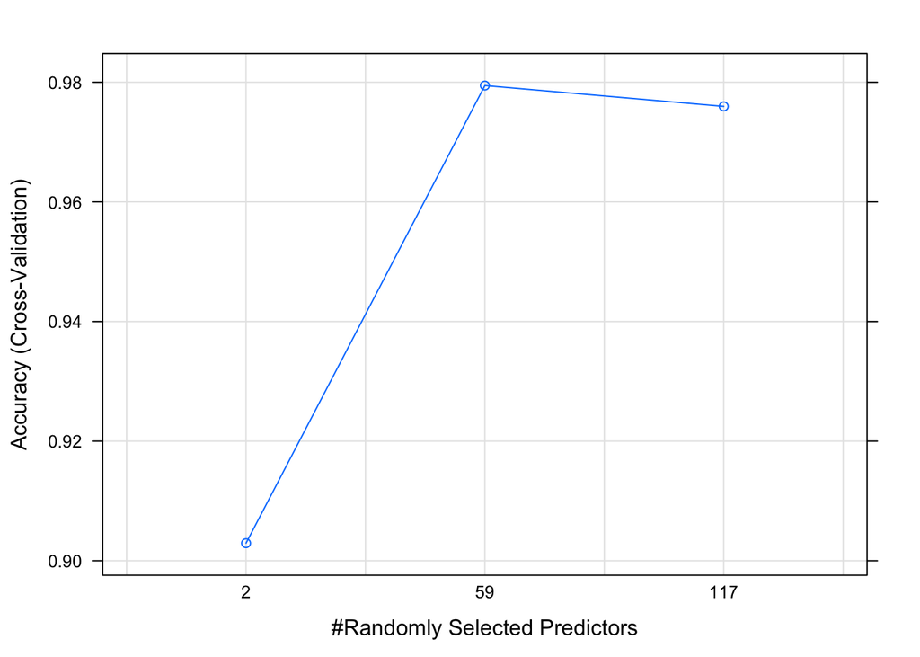

```r
plot(modelb,plotType = "line")
```

## Testing

```r
testing <- myTesting[,names(myTesting) %in% names(myTraining)]
testingPred <- predict(preObj, testing, type="class")
finalPred <- predict(modelb, newdata=testing, type = "raw")
```

## Saving the predictions for later.

```r
write.table(file = "predictions.csv", sep = ",", x = finalPred)
```

### Comparing the results

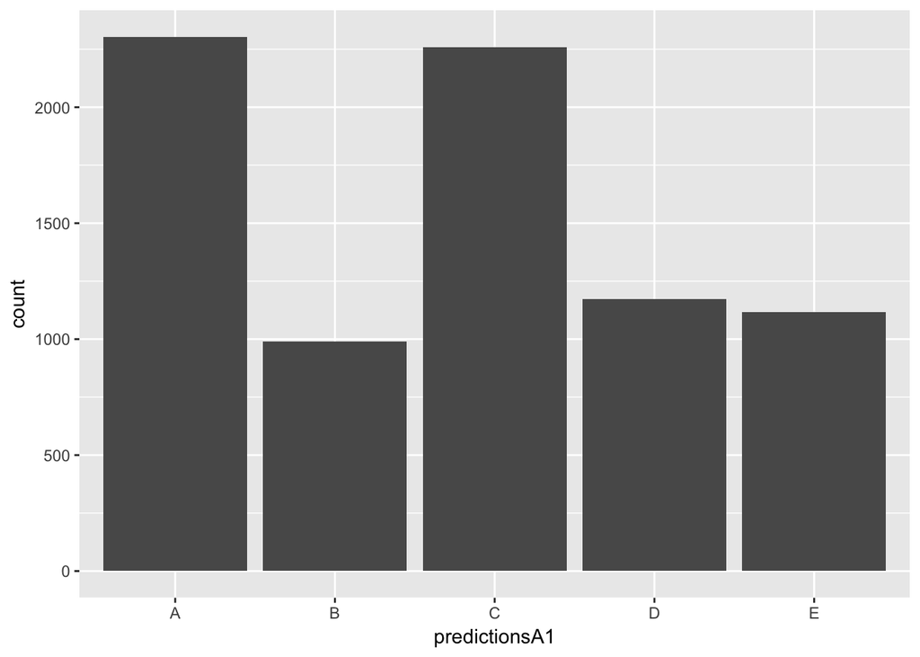

```r
qplot(predictionsA1)
```

[figure not shown]

```r
qplot(finalPred,main = "Predictions by Classe")
```